# 《R + Amos + SPSS》

王超

27-07-2026

# 1 假设检验(Hypothesis Testing)

## 1.1 假设检验理论简介

[Introduction to Hypothesis Testing](https://www.statology.org/hypothesis-testing/)

A **statistical hypothesis** is an assumption about a population parameter.

A **hypothesis test** is a formal statistical test we use **to reject** or **fail to reject** a statistical hypothesis.

There are two types of statistical hypotheses:

- The **null hypothesis( *H*₀: *µ*₁ = *µ*₂ )**, is the hypothesis that the sample data( *M*₁ ≠ *M*₂ ) occurs purely from chance.
- The **alternative hypothesis( *H*₁: *µ*₁ ≠ *µ*₂ )**, is the hypothesis that the sample data( *M*₁ ≠ *M*₂ ) is influenced by some non-random cause.

Distribution of difference

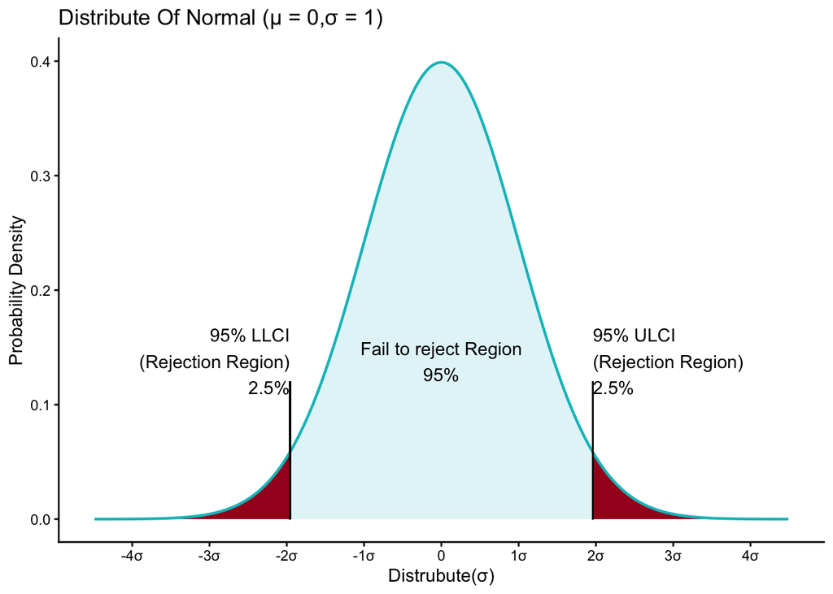

The Two Types of Decision Errors:

1. **Type I error**: You reject the null hypothesis when it is actually true(denoted as α).
2. **Type II error**: You fail to reject the null hypothesis when it is actually false(denoted as β).

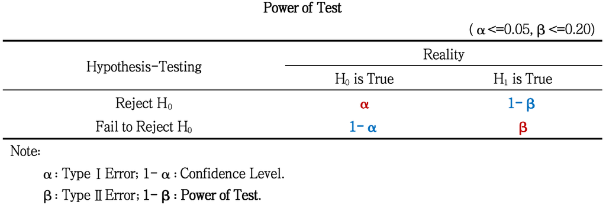

One-Tailed and Two-Tailed Tests:

1. A **two-tailed hypothesis** involves making an “equal to” or “not equal to” statement.
2. A **one-tailed hypothesis** involves making a “greater than” or “less than” statement.

## 1.2 假设检验（含相关与回归）的类别

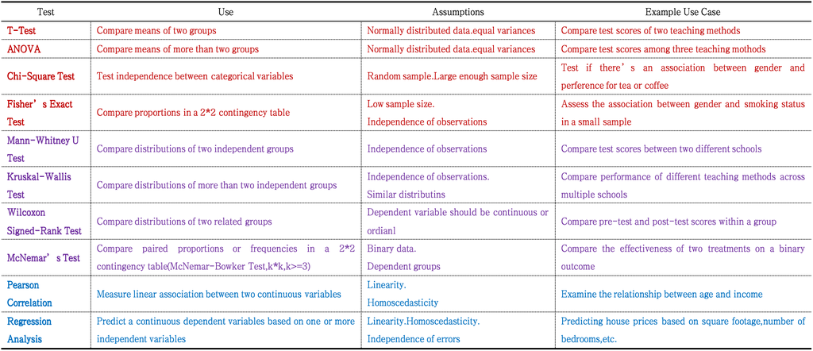

## 1.3 Effect Size and Sample Size

### 1.3.1 Effect Size

- [What It Is and Why It Matters.](https://www.statology.org/effect-size/)
- APA - Effect Size and CI(P137)
- 【参考文献】
  - 张承谦.双侧迁移训练对11-12岁青少年篮球基本技术学习效果的影响研究[D].上海体育大学,2024.DOI:10.27315/d.cnki.gstyx.2024.000135.(P22,Cohen’s d;P25,Partial Eta-Squared)

An **effect size** is a way to **quantify the difference** between two groups.

While a **p-value** can tell us **whether or not there is** a statistically significant difference between two groups, an **effect size** can tell us **how large** this difference actually is. In practice, effect sizes are much more interesting and useful to know than p-values.

P-values can be affected by **large sample sizes**. The larger the sample size, the greater the statistical power of a hypothesis test, which **enables it to detect even small effects**. This can lead to **low p-values**, despite **small effect sizes** that may **have no practical significance**.

- R Non-Parameter Test Effect Size Caculation

```r
# |  设计类型   |    整体检验           |    整体效应量     |    事后检验           |    事后效应量    |
# | ---------- | -------------------- | --------------- | -------------------- | --------------- |
# | 2 独立样本  | Mann–Whitney U       | Rank-biserial r | —                    | Rank-biserial r |
# | ≥3 独立样本 | Kruskal–Wallis       | ε² / η²[H]      | Wilcoxon rank-sum    | Rank-biserial r |
# | 2 配对样本  | Wilcoxon signed-rank | Rank-biserial r | —                    | Rank-biserial r |
# | ≥3 配对样本 | Friedman             | Kendall’s W     | Wilcoxon signed-rank | Rank-biserial r |


# ------------------------------------------------------------
# Load required R packages
# ------------------------------------------------------------
library(effectsize)  # For effect size estimation and confidence intervals
library(rstatix)     # For nonparametric tests and post hoc comparisons
library(dplyr)       # For data manipulation (data wrangling)

############################################################
# PART 1: Two Independent Samples
# Nonparametric Test: Mann–Whitney U Test
# (also known as Wilcoxon Rank-Sum Test)
############################################################

# ------------------------------------------------------------
# Prepare dataset for two independent groups
# Dependent variable: Sepal.Length
# Grouping variable: Species (two independent groups)
# ------------------------------------------------------------
data_two <- iris %>%
  filter(Species %in% c("setosa", "versicolor")) %>%
  droplevels()  # Remove unused factor levels

# ------------------------------------------------------------
# Mann–Whitney U Test
# Purpose:
#   Test whether the distributions of two independent groups differ
# ------------------------------------------------------------
cat("=== Mann–Whitney U Test Results ===\n")

mw_test <- wilcox.test(
  Sepal.Length ~ Species,
  data = data_two,
  exact = FALSE,      # Normal approximation (large samples)
  conf.int = TRUE,    # Confidence interval for location shift
  conf.level = 0.95
)

# ------------------------------------------------------------
# Effect size for Mann–Whitney U Test
# Effect size measure: Rank-biserial correlation (independent)
# ------------------------------------------------------------
effect_two <- rank_biserial(
  Sepal.Length ~ Species,
  data = data_two,
  ci = 0.95,
  verbose = FALSE
)

# Effect size name: Rank-biserial correlation (r_rb)
# Range: −1 to 1
# Interpretation:
#   r = 0 → complete overlap between groups
# r = ±1 → complete separation between groups
# Meaning:
#   Difference in probability that a randomly chosen observation from one group exceeds the other


# ------------------------------------------------------------
# Load required R packages
# ------------------------------------------------------------
library(effectsize)  # For effect size estimation and confidence intervals
library(rstatix)     # For nonparametric tests and post hoc procedures
library(dplyr)       # For data manipulation (data wrangling)
library(tidyr)       # For reshaping data (wide <-> long)

############################################################
# PART 1: Two Paired Samples
# Nonparametric Test: Wilcoxon Signed-Rank Test
############################################################

# ------------------------------------------------------------
# Read paired-sample dataset (wide format)
# Each row represents one subject
# Time2 and Time3 are two paired measurements
# ------------------------------------------------------------
data_two <- read.csv(
  "../Data/02Hypothesis_Test/非参数检验-两个配对样本-案例数据集.csv"
)

# Select the two paired variables
data_two <- data_two %>%
  select(Time2, Time3)

# ------------------------------------------------------------
# Wilcoxon Signed-Rank Test
# Purpose:
#   Test whether the median of paired differences equals zero
# ------------------------------------------------------------
w_test <- wilcox.test(
  data_two$Time2,
  data_two$Time3,
  paired = TRUE,        # Paired samples
  exact = FALSE,        # Normal approximation (large sample)
  conf.int = TRUE,      # Confidence interval for location shift
  conf.level = 0.95
)

print(w_test)

# ------------------------------------------------------------
# Effect size for paired Wilcoxon test
# Effect size measure: Rank-biserial correlation (paired version)
# ------------------------------------------------------------
effect_two <- rank_biserial(
  data_two$Time2,
  data_two$Time3,
  paired = TRUE,        # Paired-sample version
  ci = 0.95,            # 95% confidence interval
  verbose = FALSE
)

print(effect_two)

# Effect size name: Rank-biserial correlation (r_rb, paired)
# Interpretation:
#   r = ±1 → all paired differences in the same direction
# r = 0 → symmetric differences
# Advantage:
#   Nonparametric
# Distribution-free
# Directly interpretable as dominance probability
```

[output not shown]

### 1.3.2 Sample Size

[G*Power](https://www.psychologie.hhu.de/arbeitsgruppen/allgemeine-psychologie-und-arbeitspsychologie/gpower)

- 【参考文献】
  - 安丽娜.团体心理辅导对失独老人认知功能的干预研究[D].武汉科技大学,2021.DOI:10.27380/d.cnki.gwkju.2021.000310.(P4,t-Test-Independent)
  - 常琳.紧身装备对半程马拉松跑者不同跑步阶段下肢本体感觉、动态平衡能力和疲劳的影响[D].上海体育学院,2020.DOI:10.27315/d.cnki.gstyx.2020.000576.(P11,Repeated-Measurement Within)
- 中等效应量对应的样本量

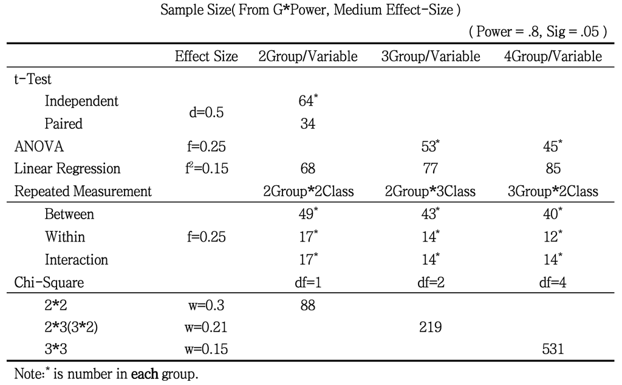

## 1.4 t检验

【交互式ShinyApps】

- 固定均值、标准差，观测**样本量变化**对 **p** 值的影响
- 假设检验结果： **p-value**、**Effect Size**、**p-value & Effect Size**
- [t检验链接](http://110.40.140.177:3838/t-Test/t-Test.Rmd)

【参考文献】

- 刘天一.运动教育模式对高中生足球运动技能、体育学习兴趣及团队凝聚力的影响研究[D].上海体育大学,2024.DOI:10.27315/d.cnki.gstyx.2024.000221.(P20)

### 1.4.1 两个独立样本t检验

[Two Sample t-test](https://www.statology.org/two-sample-t-test/)

Two Sample t-test: Assumptions:

- The observations in one sample should **be independent of** the observations in the other sample.
- The data should **be approximately normally distributed**.
- The two samples should **have approximately the same variance**.

### 1.4.2 两个配对样本t检验

[Paired Samples t-test](https://www.statology.org/paired-samples-t-test/)

Paired Samples t-test: Assumptions:

- **The differences** between the pairs should **be approximately normally distributed**.
- There should be **no extreme outliers** in the differences.

### 1.4.3 t 检验案例复现

【案例数据集】

- t检验-案例数据集链接
- t检验-案例数据集（CHG）链接

【操作视频】

- 独立样本t检验-操作视频链接
- 成对样本t检验-操作视频链接

【结果呈现】

- 结果汇报推荐格式

【交互式可视化】

- [箱线图绘制链接](http://110.40.140.177:3838/Plot-Box/Plot-Box.Rmd)
- [雷达图绘制链接](http://110.40.140.177:3838/Plot-Radar/Plot-Radar.Rmd)

【APA格式标准】

- Publication Manual of the American Psychological Association (APA)

## 1.5 非参数检验

- 【参考文献】
  - 苏杉.3～6岁幼儿身体活动、基本动作技能及其相关性研究[D].上海体育学院,2022.DOI:10.27315/d.cnki.gstyx.2022.000177.(P23,28-29)
- Nonparametric Tests-Methods, Tests, and Effect Sizes

### 1.5.1 两独立样本非参数检验

- **Mann-Whitney U**检验[Mann-Whitney U](https://www.statology.org/mann-whitney-u-test/)
- A **Mann-Whitney U test** (sometimes called the Wilcoxon rank-sum test) is used to compare the differences between two independent samples when the sample distributions are **not normally distributed** and **the sample sizes are small (n <30)**.
- 【案例数据集】
  - 检验变量:Petal.Width;分组变量:Species=1,2
  - 非参数检验-两个独立样本案例数据集链接
- 【操作视频】
  - 非参数检验-两个独立样本操作视频链接
- 【结果呈现】
  - 结果汇报推荐格式

### 1.5.2 多独立样本非参数检验

- **Kruskal-Wallis**检验[Kruskal-Wallis Test](https://www.statology.org/kruskal-wallis-test/)
- A **Kruskal-Wallis test** is used to determine whether or not there is a statistically significant difference **between the medians of three or more** independent groups.
- 【案例数据集】
  - 检验变量:Petal.Width;分组变量:Species=1,2,3
  - 非参数检验-多个独立样本案例数据集链接
- 【操作视频】
  - 非参数检验-多个独立样本操作视频链接
- 【结果呈现】
  - 结果汇报推荐格式

### 1.5.4 多配对样本非参数检验

- 【参考文献】
  - 杨莉群.SMILE矫正散光的疗效分析：动态评估、术式对比及散光成分分析[D].吉林大学,2025.DOI:10.27162/d.cnki.gjlin.2025.005446.(P20,27)
- **Friedman**检验[Friedman Test](https://www.statology.org/friedman-test/)
- **The Friedman Test** is a non-parametric alternative to **the Repeated Measures ANOVA**.It is used to determine whether or not there is a statistically significant difference **between the means of three or more groups** in which the same subjects show up in each group.
- 【案例数据集】
  - 检验变量:Time1,Time2,Time3
  - 非参数检验-多个配对样本案例数据集链接
- 【操作视频】
  - 非参数检验-多个配对样本操作视频链接
- 【结果呈现】
  - 结果汇报推荐格式

## 1.6 方差齐性检验

【交互式ShinyApps】

- 方差齐性/方差不齐时，假设检验方法（参数/非参数）的选择
- [方差齐性/不齐对假设检验结果的影响](http://110.40.140.177:3838/Homoscedasticity/Homoscedasticity.Rmd)

## 1.7 卡方检验

### 1.7.1 独立样本卡方检验

【卡方检验方法】

- **Chi-Square Test of Independence**检验[Chi-Square Test of Independence](https://www.statology.org/chi-square-test-of-independence-spss/)
- A **Chi-Square Test of Independence** is used to determine whether or not there is a significant association **between two categorical variables**.

【参考文献】

- 郑李.两种复合运动对胰岛素抵抗型肥胖儿童青少年健康和代谢体适能影响的研究[D].广州体育学院,2024.DOI:10.27042/d.cnki.ggztc.2024.000069.(论文第23,29页)
- 李聪,万玉,王梦,等.膝三针温针灸配合微波照射治疗KOA的疗效及对微循环、血管炎症的影响[J].检验医学与临床,2024,21(12):1790-1794+1800.

【案例数据集】

- 卡方检验-独立样本案例数据集-原始数据链接
- 卡方检验-独立样本案例数据集链接

【操作视频】

- 卡方检验-独立样本操作视频链接

【结果呈现】

- 结果汇报推荐格式

### 1.7.2 配对样本卡方检验

- **McNemar’s Test**[McNemar’s Test](https://www.statology.org/mcnemars-test-spss/)
- **Cohen’s Kappa**[Cohen’s Kappa](https://www.statology.org/cohens-kappa-spss/)
- **McNemar’s Test** is used to determine if there is a statistically significant difference in proportions **between paired data**.
- **Cohen’s Kappa** is used to measure **the level of agreement** between two raters or judges who each classify items into mutually exclusive categories.
  - Null Hypothesis: κ = 0, Alternative Hypothesis: κ ≠ 0

【参考文献】

- 【新辅助治疗前后生物标志物表达与疗效和预后的相关性研究(论文第17-18页)】
- 【北京体育大学青训男子足球运…员体能现状及评价标准的研制(论文第38页)

【案例数据集】

- 卡方检验-配对样本案例数据集链接

【操作视频】

- 卡方检验-配对样本操作视频链接

【结果呈现】

- 结果汇报推荐格式